# 04 - Predictor vs Target EDA: BodyFat

## 1 Objective

This report examines the individual relationship between each predictor and the target `BodyFat` after removing the leakage variable `Density`.

It includes: 1. A faceted scatter-plot grid (one panel per predictor) with linear trend lines, 95% confidence bands, and per-panel Pearson correlation. 2. A ranked bar chart of absolute Pearson correlations with `BodyFat`. 3. A focused `Abdomen` vs `BodyFat` scatter plot colored by age group to explore possible age-related effect modification.

## 2 Setup and Data

```r
library(tidyverse)

bodyfat_raw <- read_csv("data/bodyfat.csv", show_col_types = FALSE)

# Remove leakage variable before any predictor-vs-target analysis
bodyfat <- bodyfat_raw %>%
  select(-Density)

predictor_names <- setdiff(names(bodyfat), "BodyFat")

# Pearson correlation of each predictor with BodyFat
corr_tbl <- map_dfr(predictor_names, function(v) {
  tibble(
    Predictor = v,
    pearson_r = cor(bodyfat[[v]], bodyfat$BodyFat, use = "complete.obs")
  )
}) %>%
  mutate(abs_r = abs(pearson_r)) %>%
  arrange(desc(abs_r))

corr_tbl
```

```
# A tibble: 13 × 3
   Predictor pearson_r  abs_r
   <chr>         <dbl>  <dbl>
 1 Abdomen      0.813  0.813
 2 Chest        0.703  0.703
 3 Hip          0.625  0.625
 4 Weight       0.612  0.612
 5 Thigh        0.560  0.560
 6 Knee         0.509  0.509
 7 Biceps       0.493  0.493
 8 Neck         0.491  0.491
 9 Forearm      0.361  0.361
10 Wrist        0.347  0.347
11 Age          0.291  0.291
12 Ankle        0.266  0.266
13 Height      -0.0895 0.0895
```

## 3 1. Faceted Scatter Plot Grid with Linear Trend and 95% CI

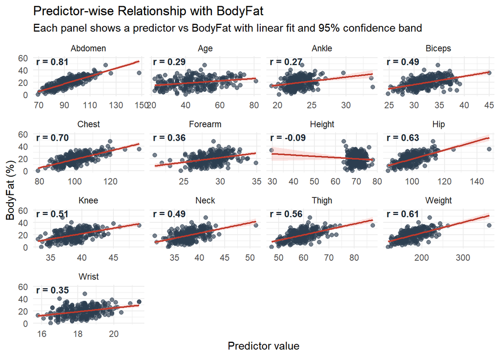

```r
plot_data_long <- bodyfat %>%
  pivot_longer(
    cols = all_of(predictor_names),
    names_to = "Predictor",
    values_to = "Value"
  )

corr_labels <- corr_tbl %>%
  transmute(
    Predictor,
    label = paste0("r = ", sprintf("%.2f", pearson_r))
  )

p_faceted <- ggplot(plot_data_long, aes(x = Value, y = BodyFat)) +
  geom_point(alpha = 0.65, color = "#2C3E50", size = 1.8) +
  geom_smooth(method = "lm", se = TRUE, color = "#C0392B", fill = "#F5B7B1", linewidth = 0.8) +
  geom_text(
    data = corr_labels,
    aes(x = -Inf, y = Inf, label = label),
    inherit.aes = FALSE,
    hjust = -0.1,
    vjust = 1.2,
    size = 3.3,
    color = "#1B2631",
    fontface = "bold"
  ) +
  facet_wrap(~ Predictor, scales = "free_x", ncol = 4) +
  labs(
    title = "Predictor-wise Relationship with BodyFat",
    subtitle = "Each panel shows a predictor vs BodyFat with linear fit and 95% confidence band",
    x = "Predictor value",
    y = "BodyFat (%)"
  ) +
  theme_minimal(base_size = 11)

p_faceted
```

Interpretation: - The panel annotations (`r`) make it easy to compare single-predictor strength at a glance. - Most body-circumference predictors show positive and approximately linear trends with `BodyFat`. - Limb measurements (for example, `Wrist`, `Ankle`) appear weaker than torso-centric variables.

## 4 2. Ranked Absolute Correlation with BodyFat

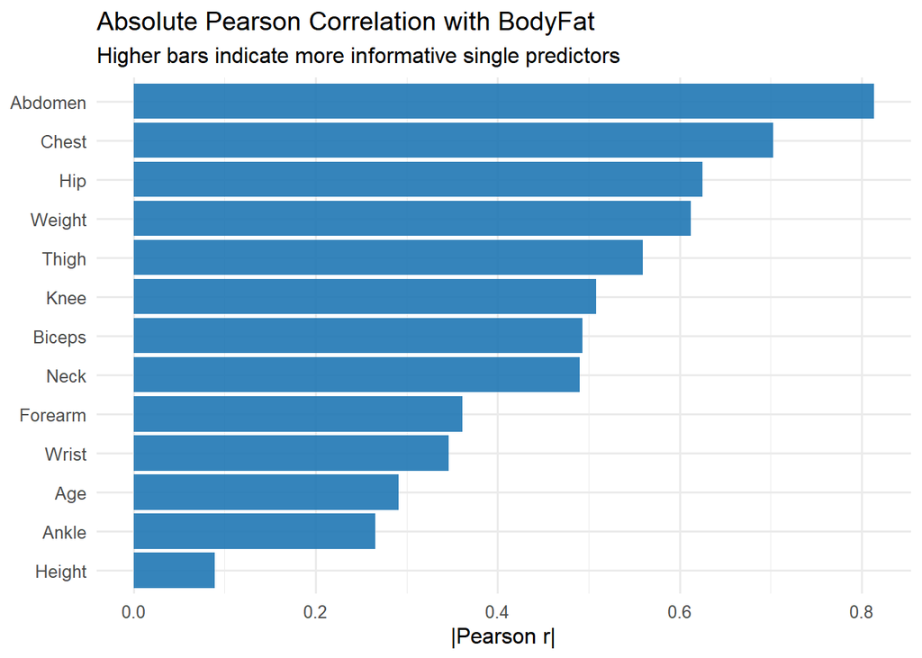

```r
corr_ranked <- corr_tbl %>%
  mutate(Predictor = fct_reorder(Predictor, abs_r))

p_ranked <- ggplot(corr_ranked, aes(x = Predictor, y = abs_r)) +
  geom_col(fill = "#1F77B4", alpha = 0.9) +
  coord_flip() +
  labs(
    title = "Absolute Pearson Correlation with BodyFat",
    subtitle = "Higher bars indicate more informative single predictors",
    x = NULL,
    y = "|Pearson r|"
  ) +
  theme_minimal(base_size = 12)

p_ranked
```

Key result: - The strongest single predictor by absolute Pearson correlation is Abdomen (`|r| = 0.813).

## 5 3. Abdomen vs BodyFat by Age Group

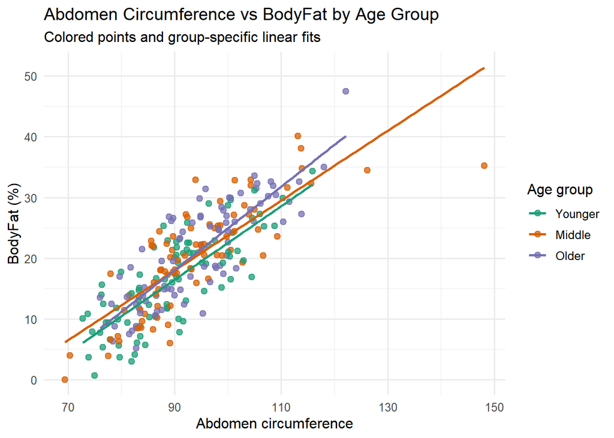

```r
bodyfat_age <- bodyfat %>%
  mutate(
    AgeGroup = ntile(Age, 3),
    AgeGroup = factor(AgeGroup, labels = c("Younger", "Middle", "Older"))
  )

p_abdomen_age <- ggplot(bodyfat_age, aes(x = Abdomen, y = BodyFat, color = AgeGroup)) +
  geom_point(alpha = 0.75, size = 2.1) +
  geom_smooth(method = "lm", se = FALSE, linewidth = 0.9) +
  scale_color_manual(values = c("Younger" = "#1B9E77", "Middle" = "#D95F02", "Older" = "#7570B3")) +
  labs(
    title = "Abdomen Circumference vs BodyFat by Age Group",
    subtitle = "Colored points and group-specific linear fits",
    x = "Abdomen circumference",
    y = "BodyFat (%)",
    color = "Age group"
  ) +
  theme_minimal(base_size = 12)

p_abdomen_age
```

```r
# Quantify evidence of curvature in the Abdomen-BodyFat relationship
abdomen_lm_linear <- lm(BodyFat ~ Abdomen, data = bodyfat)
abdomen_lm_quadratic <- lm(BodyFat ~ Abdomen + I(Abdomen^2), data = bodyfat)
curvature_test <- anova(abdomen_lm_linear, abdomen_lm_quadratic)
quad_p_value <- curvature_test$`Pr(>F)`[2]

# Quantify whether age group modifies the Abdomen slope
abdomen_age_main <- lm(BodyFat ~ Abdomen + AgeGroup, data = bodyfat_age)
abdomen_age_interaction <- lm(BodyFat ~ Abdomen * AgeGroup, data = bodyfat_age)
interaction_test <- anova(abdomen_age_main, abdomen_age_interaction)
interaction_p_value <- interaction_test$`Pr(>F)`[2]

list(
  quadratic_term_p_value = quad_p_value,
  abdomen_age_interaction_p_value = interaction_p_value
)
```

```
$quadratic_term_p_value
[1] 0.0001233328

$abdomen_age_interaction_p_value
[1] 0.2599698
```

## 6 Findings

- Torso measurements dominate the single-variable signal for `BodyFat`, with `Abdomen` expected to be among the top features.
- The predictor-vs-target panels mostly support an approximately linear pattern, especially for stronger circumference predictors.
- For `Abdomen` specifically, the linear trend is strong and visually tight. Use the quadratic-term p-value above to check for curvature; if it is not small, the linear approximation is likely adequate.
- The age-colored scatter and group-specific lines show whether slope/intercept differ by age tercile. If the interaction p-value is not small, age does not strongly modify the Abdomen-BodyFat slope in this sample.

Overall, the plots and rankings reinforce that central body-size measurements are the most informative single predictors of body fat in this dataset.